[figure not shown]

Nonparametric Tests

Charles Hwang

Background

●Nonparametric statistics is an entire subsection of statistics

○STAT 351/488 - Nonparametric Statistical Methods1offered at Loyola

every spring semester

●Nonparametric tests can be used when assumptions of traditional tests are

violated

○Most real-world data are not normally distributed

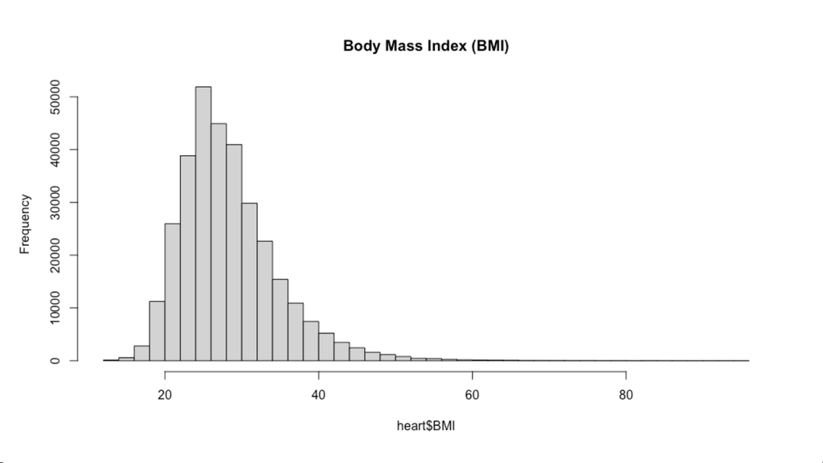

Concepts

●Median (m)

○Not unduly influenced by outliers or distribution

●Ordinal data (Likert scale, rating, education level, etc.)

●Order statistics (rank)

Advantages

●Tests make fewer assumptions

○Tests are often as or more robust than traditional tests

●Methods can be easier to use and interpret

Disadvantages

●Some tests have less power (larger nneeded)

●Generally less commonly used and recognized

●Some tests don’t have test statistics (only p-values)

○Example: Fisher’s exact test

(Incomplete) List of Methods2

●Analysis of similarities

●Anderson–Darling test

●Bootstrap methods

●Cochran’s Q

●Cohen’s κ

●Friedman two-way ANOVA by ranks

●Kaplan–Meier

●Kendall’s τ

●Kendall’s W

●Kolmogorov–Smirnov test

●Kruskal–Wallis one-way ANOVA by ranks

●Kuiper’s test

●Log-rank test

●Mann–Whitney U(Wilcoxon rank sum) test

●McNemar’s test

●Median test

●Pitman’s permutation test

●Rank products

●Siegel–Tukey test

●Sign test

●Spearman’s ρ

●Squared ranks test

●Tukey–Duckworth test

●Wald–Wolfowitz runs test

●Wilcoxon signed-rank test

(Incomplete) List of Methods2

●Analysis of similarities: tests similarities between groups against similarities within groups

●Anderson–Darling test: tests whether a sample is drawn from a given distribution

●Bootstrap methods: estimates the accuracy/sampling distribution of a statistic

●Cochran’s Q: tests whether k treatments in randomized block designs with 0/1 outcomes have identical effects

●Cohen’s κ: measures inter-rater agreement for categorical items

●Friedman two-way ANOVA by ranks: tests whether k treatments in randomized block designs have identical effects

●Kaplan–Meier: estimates the survival function from lifetime data, modeling censoring

●Kendall’s τ: measures statistical dependence between two variables

●Kendall’s W: a measure between 0 and 1 of inter-rater agreement

●Kolmogorov–Smirnov test: tests whether a sample is drawn from a given distribution, or whether two samples are

drawn from the same distribution

●Kruskal–Wallis one-way ANOVA by ranks: tests whether > 2 independent samples are drawn from the same

distribution

●Kuiper’s test: tests whether a sample is drawn from a given distribution, sensitive to cyclic variations such as day of

the week

●Log-rank test: compares survival distributions of two right-skewed, censored samples

●Mann–Whitney U(Wilcoxon rank sum) test: tests whether two samples are drawn from the same distribution, as

compared to a given alternative hypothesis

●McNemar’s test: tests whether, in 2 × 2 contingency tables with a dichotomous trait and matched pairs of subjects,

row and column marginal frequencies are equal

●Median test: tests whether two samples are drawn from distributions with equal medians

●Pitman’s permutation test: a statistical significance test that yields exact p values by examining all possible

rearrangements of labels

●Rank products: detects differentially expressed genes in replicated microarray experiments

●Siegel–Tukey test: tests for differences in scale between two groups

●Sign test: tests whether matched pair samples are drawn from distributions with equal medians

●Spearman’s ρ: measures statistical dependence between two variables using a monotonic function

●Squared ranks test: tests equality of variances in two or more samples

●Tukey–Duckworth test: tests equality of two distributions by using ranks

●Wald–Wolfowitz runs test: tests whether the elements of a sequence are mutually independent/random

●Wilcoxon signed-rank test: tests whether matched pair samples are drawn from populations with different mean

ranks

(Incomplete) List of Methods

●Analysis of similarities

●Anderson–Darling test

●Bootstrap methods

●Cochran’s Q

●Cohen’s κ

●Friedman two-way ANOVA by ranks

●Kaplan–Meier

●Kendall’s τ

●Kendall’s W

●Kolmogorov–Smirnov test

●Kruskal–Wallis one-way ANOVA by ranks

●Kuiper’s test

●Log-rank test

●Mann–Whitney U(Wilcoxon rank sum) test

●McNemar’s test

●Median test

●Pitman’s permutation test

●Rank products

●Siegel–Tukey test

●Sign test

●Spearman’s ρ

●Squared ranks test

●Tukey–Duckworth test

●Wald–Wolfowitz runs test

●Wilcoxon signed-rank test

Kendall’s τ

●Take all nC2= n(n-1) / 2 pairs of points

●A pair is concordant if xi< xjand yi< yj

●A pair is discordant if xi< xjand yi> yj

●τ= (concordant - discordant) / nC2

●Ties (if xi= xjor yi= yj)

○τA(ignore)

○τB(RStudio)

○τC(Stuart–Kendall)

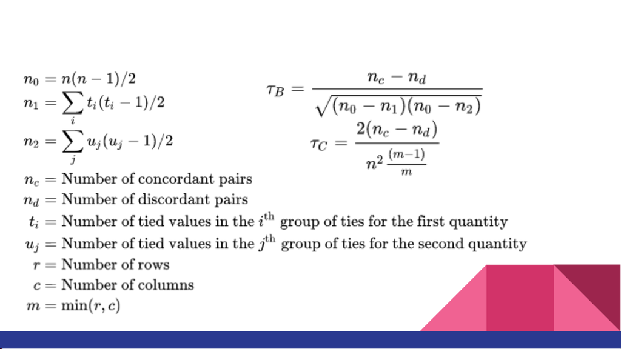

3

Kendall’s τ

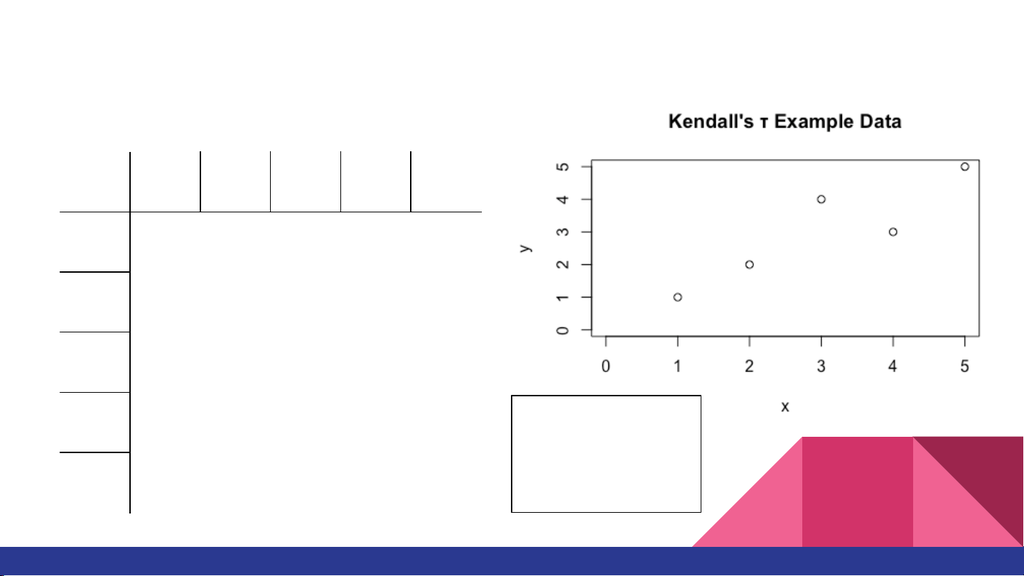

Kendall’s τExample

j

(1,1)

(2,2)

(3,4)

(4,3)

(5,5)

i

(1,1)

C C C C

(2,2)

C C C

(3,4)

D C

(4,3)

C

(5,5)

cor(x,y,method=”kendall”)

C = 9, D = 1

τ= (9 - 1) / 10 =

τ= 0.8

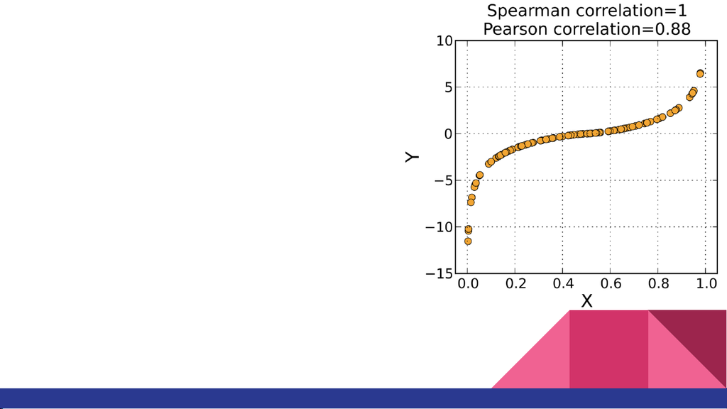

Spearman’s ρ

●Calculates ron ranks

○Ties: fractional (mean) ranks

●Not unduly affected by outliers or

influential points

●Useful for data resembling a monotonic

function (exponential, logistic,

logarithmic, etc.)

●cor(x,y,method=”spearman”)

4

Sign test (paired or one-sample)

●Points where xi> yiare ⊕

●Points where xi= yiare ∅

●Points where xi< yiare ⊖

●One-sample: replace yiwith η(estimated population median)

●H0: mx-my= d; HA: mx-my≠ dor H0: m= η;

HA: m≠ η

●p= 2 * Binomcdf(⊕; n-∅, 0.5)

●Disadvantage: Low power

Sign test (paired, H0: mx-my= 0)

x01233456778910

y1243456788999

Sgn

⊖ ⊖ ⊖ ∅ ⊖ ⊖ ⊖ ⊖ ⊖ ⊖ ⊖ ∅ ⊕

p= 2 * Binomcdf(⊕; n-∅, 0.5) = 2 * Binomcdf(1; 13 - 2, 0.5) = 0.01171875

binom.test(1,11,p=0.5,alternative=“two.sided”)

[figure not shown]

Sign test (one-sample, H0: m= 1)

binom.test(11,12,p=0.5,alternative=“two.sided”)

x01233456778910

Sgn

⊖ ∅ ⊕⊕⊕⊕⊕⊕⊕⊕⊕⊕⊕

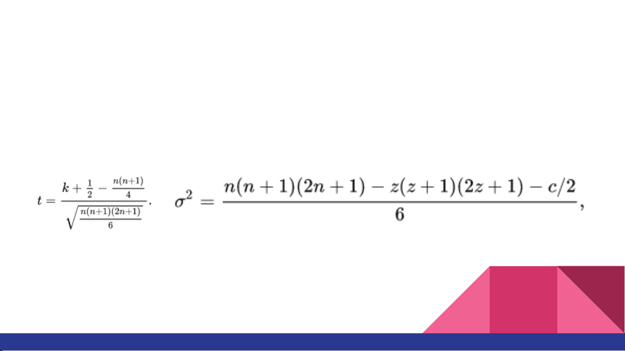

Wilcoxon signed-rank test

●Similar to sign test

●Points are sorted by absolute difference and ranked (ties ignored)

●W-+ W+= W= n(n+1) / 2

5

[figure not shown]

Wilcoxon signed-rank test (paired, H0: mx= my)

x

100

101

102

103

103

104

105

106

107

107

108

109

110

y

101

100

99 98 97 96 95 94 93 93 92 92 92

Diff.

-1 1 3 5 6 8 10 12 14 14 16 17 18

Ri1.5 1.5 3 4 5 6 7 8 9.5 9.5 11 12 13

W-= 1.5

W+= 1.5 + 3 + 4 + 5 + 6 + 7 + 8 + 9.5 + 9.5 + 11 + 12 + 13 = 89.5

W= 89.5, p= 0.002351027

wilcox.test(x,y,paired=TRUE)

Wilcoxon signed-rank test (one-sample, H0: m= 0)

x01233456778910

Diff.

01233456778910

Ri—1 2 3.5 3.5 5 6 7 8.5 8.5 10 11 12

W-= 0

W+= 1 + 2 + 3.5 + 3.5 + 5 + 6 + 7 + 8.5 + 8.5 + 10 + 11 + 12 = 78

W= 78, p= 0.002506842

wilcox.test(x,alternative=”two.sided”)

[figure not shown]

Mann–Whitney U(Wilcoxon rank sum) test

●Similar family of tests for non-paired two-sample

●H0: mx-my= d;HA: mx-

my≠ d

●U1= Σi=1n1R1-n2(n2+1)/2 U2= Σi=1n2R2-

n1(n1+1)/2 6

Mann–Whitney U(Wilcoxon rank sum) test

U1= 1 + 2 + 3 + 4.5 + 6 + 8 - n2(n2+1)/2 = 24.5 - 6*7/2 = 3.5

W= 3.5, p= 0.01488064

wilcox.test(x,y,alternative=”two.sided”)

x, y01233456778910

Rx1 2 3 4.5 6 8

Ry4.5 7 9.5 9.5 11 12 13

Kolmogorov–Smirnov test

●One-sample (Kolmogorov) or two-sample (Smirnov)

●H0: The data are from a certain/the same distribution

●HA: The data are not from a certain/the same distribution

●Disadvantage: less power

○Normal distribution: Shapiro–Wilk test

○Anderson–Darling test gives more weight to tails

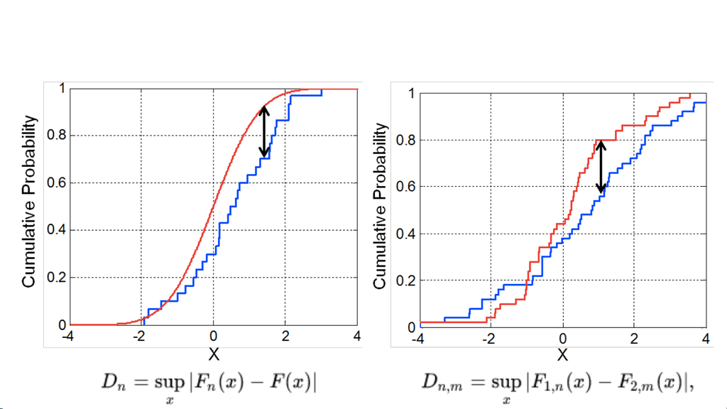

Kolmogorov–Smirnov test7ks.test(x,y)

[figure not shown]

McNemar’s (MACK-neh-MARS) test

●Tests for marginal homogeneity (paired data)

●H0: b= c; HA: b≠ c

●χ2(1) = (b-c)2/ (b+ c)

●mcnemar.test(x)

2

×

2

Y N

Tot

Ya b

a

+

b

Nc d

c

+

d

Tot

a

+

c

b

+

d

n

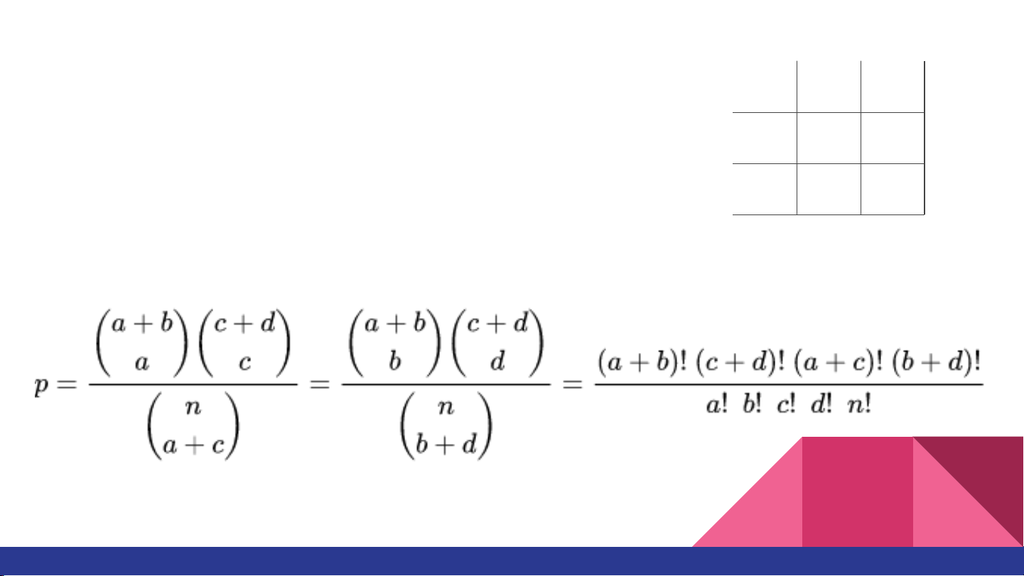

Bonus: Fisher’s exact test

●H0: The two variables are independent

●HA: The two variables are not independent

● fisher.test(x,alternative=”two.sided”)

8

2

×

2

Tot

a b

a

+

b

c d

c

+

d

Tot

a

+

c

b

+

d

n

Conclusion

●Nonparametric statistics is an entire subsection of statistics

●Nonparametric tests can be used when assumptions of traditional tests are

violated

○Most real-world data are not normally distributed

[figure not shown]

References

1. https://www.luc.edu/media/lucedu/math/docs/Stat-Grid.pdf

a. Hollander, Myles, Douglas A. Wolfe and Eric Chicken. Nonparametric Statistical

Methods. 3rd ed., Wiley-Blackwell, 2014.

2. https://en.wikipedia.org/wiki/Nonparametric_statistics#Methods

3. https://en.wikipedia.org/wiki/Kendall_rank_correlation_coefficient#Accounting_for_ties

4. https://commons.wikimedia.org/wiki/File:Spearman_fig1.svg

5. https://en.wikipedia.org/wiki/Wilcoxon_signed-rank_test#Computing_the_null_distribution

6. https://en.wikipedia.org/wiki/Mann%E2%80%93Whitney_U_test

7. https://en.wikipedia.org/wiki/Kolmogorov%E2%80%93Smirnov_test

a. https://commons.wikimedia.org/wiki/File:KS_Example.png

b. https://commons.wikimedia.org/wiki/File:KS2_Example.png

8. https://en.wikipedia.org/wiki/Fisher%27s_exact_test#Example

[figure not shown]

Questions?